# Lab 02 - Visualización

## Ejercicio 1

Utilizando los datos de la librería `gapminder`:

- Filtra las obserevaciones correspondientes a los años 1957, 1967, 1977, 1987, 1997, 2007
- Representa la relación entre PIB per cápita y esperanza de vida por continentes y por años en diferentes gráficas usando **faceting**. El tamaño de los puntos ha de ser proporcional a la población. El color debe reflejar el continente.
- ¿Qué conlusiones extraes?

### Solución

Cargamos los paquetes necesarios

```r
library(gapminder)
library(tidyverse)
unique(gapminder$year)
```

```
##  [1] 1952 1957 1962 1967 1972 1977 1982 1987 1992 1997 2002 2007
```

Filtramos las observaciones de los años 1957, 1967, 1977, 1987, 1997, 2007

```r
years <- c(1957, 1967, 1977, 1987, 1997, 2007)
gapminder_filter <- gapminder %>% filter(year %in% years)
```

Representamos gráficamente

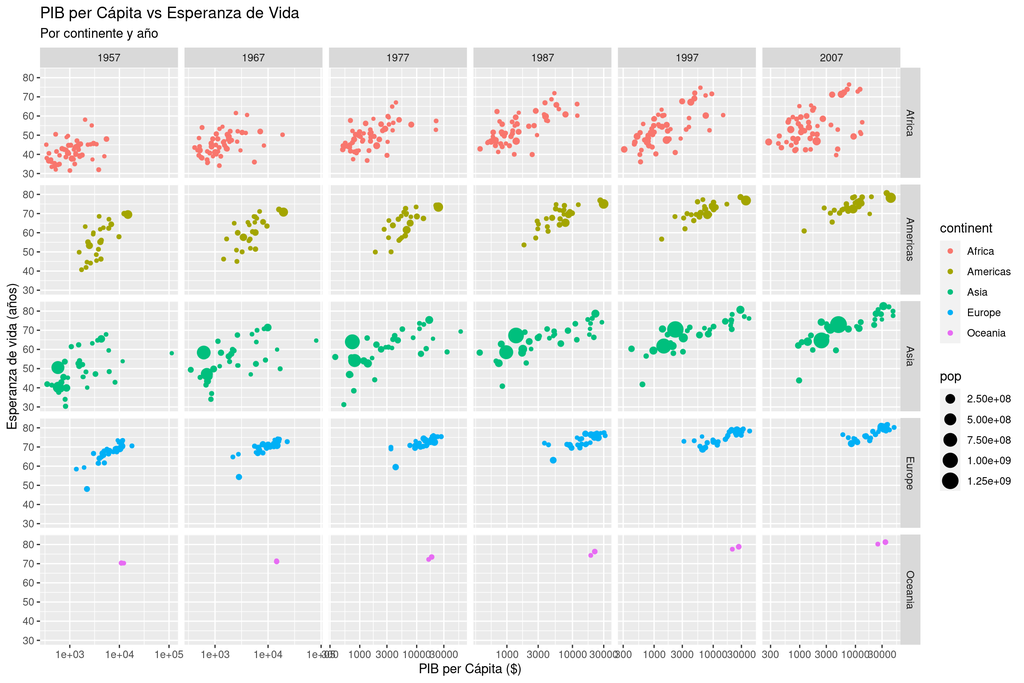

```r
ggplot(data = gapminder_filter, aes(x = gdpPercap, y = lifeExp,
                                    size=pop, color=continent)) +
  geom_point() +
  labs(title = "PIB per Cápita vs Esperanza de Vida",
       subtitle = "Por continente y año",
       x = "PIB per Cápita ($)", y =  "Esperanza de vida (años)") +
  scale_x_log10() +
  facet_grid(continent ~ year, scales = "free_x")
```

## Ejercicio 2

La contaminación debida al consume de plástico es un problema global que afecta negativamente a la salud de diversos ecosistemas. [Our World in Data](https://ourworldindata.org/plastic-pollution) contiene multitud de datos acerca de la evolución del consumo de plástico tanto a nivel global, como de país. Para este ejercicio nos centramos en los datos de 2010.

Los datos se encuentran en la carpeta data del repositorio. Puedes cargarlos utilizando

```r
library(tidyverse)
plastic <- read_csv("data/plastic-waste.csv")
```

Las variables son las siguientes

- `code`: Código de país (3 letras)
- `entity`: Nombre completo del país
- `continent`: Nombre del continente
- `year`: Año
- `gdp_per_cap`: PIB per cápita (2011) en dólares internacionales
- `plastic_waste_per_cap`: Cantidad de residuos per capita de plástico en kg/día
- `mismanaged_plastic_waste_per_cap`: Cantidad de residuos de plástico mal gestionados en kg/día
- `mismanaged_plastic_waste`: Toneladas de residuos de plástico mal gestionados
- `coastal_pop`: Número de individuos que viven en o cerca de la cosa
- `total_pop`: Población total

Visualiza la distribución de la cantidad de residuos de plástico per cápita (en 2010).

¿Existe algún valor atípico? Si es así, determina qué países son atípicos. Trata de mostrar si son o no datos erróneos (investigando en internet).

Nota: Para el resto de ejercicios, filtra los datos atípicos si los hubiera.

### Solución

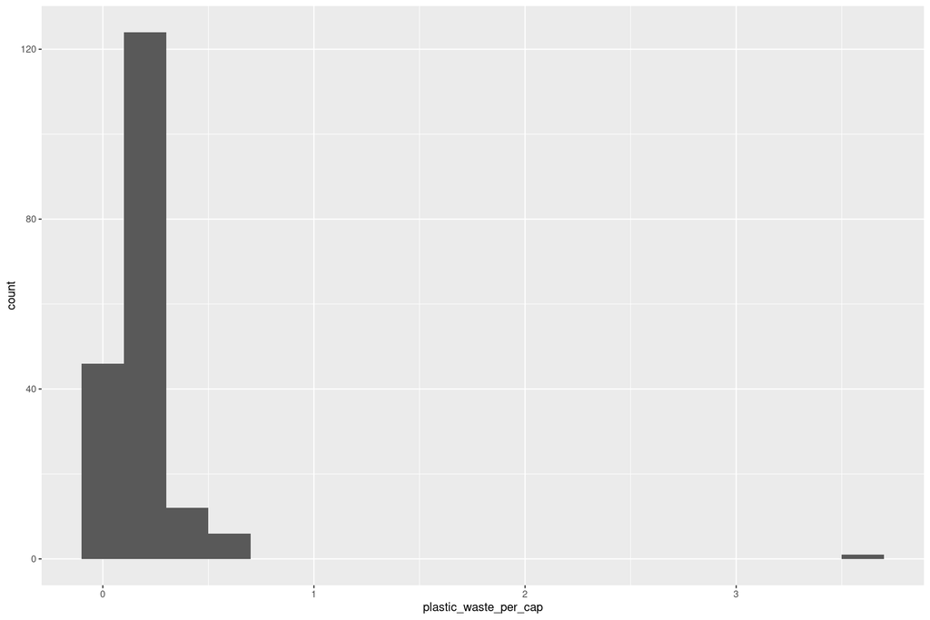

```r
ggplot(data = plastic, aes(x = plastic_waste_per_cap)) +
  geom_histogram(binwidth = 0.2)
```

```r
plastic %>%
  filter(plastic_waste_per_cap > 3.5)  %>%
  select(entity)
```

```
## # A tibble: 1 × 1
##   entity
##   <chr>
## 1 Trinidad and Tobago
```

```r
plastic <- plastic %>%
  filter(plastic_waste_per_cap < 3.5)
```

## Ejercicio 3

Visualiza la distribución de la cantidad de residuos de plástico per capita por continente, usando distintos histogramas para cada continente.

### Solución

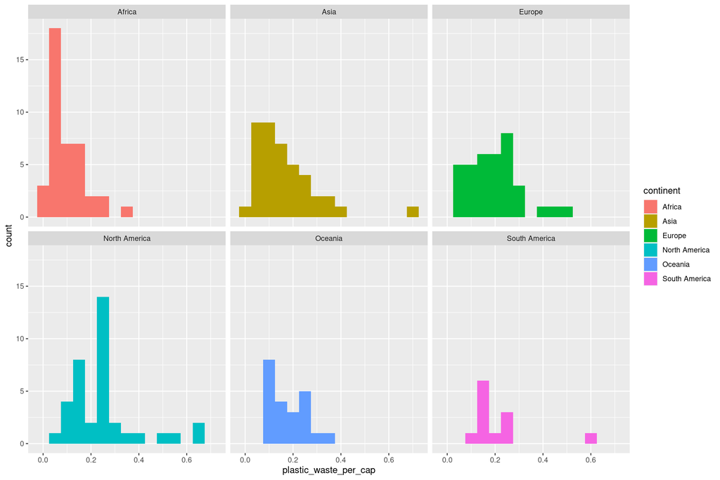

```r
ggplot(data = plastic, aes(x = plastic_waste_per_cap, fill = continent)) +
  geom_histogram(binwidth = 0.05) + facet_wrap(continent~.)
```

## Ejercicio 4

Repite la gráfica anterior usando densidad, incluyendo todos los continentes en la misma gráfica indicándolos con distintos colores.

### Solución

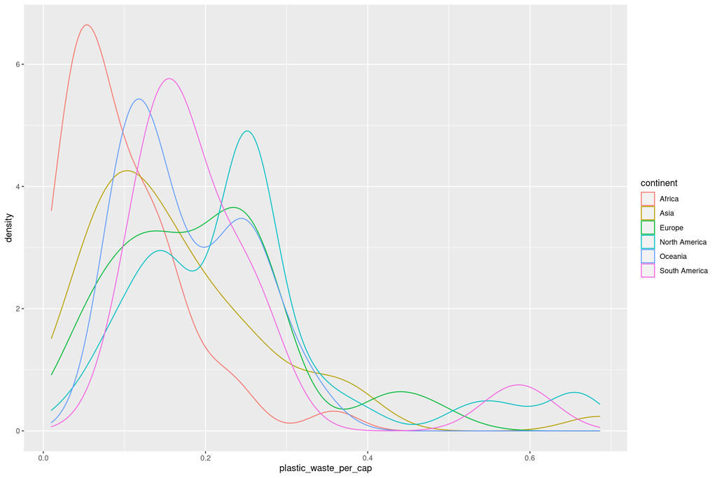

```r
ggplot(data = plastic,
       mapping = aes(x = plastic_waste_per_cap,
                     color = continent)) +
  geom_density()
```

## Ejercicio 5

Mejora la gráfica anterior pintando cada curva de un color y añadiendo transparencia.

### Solución

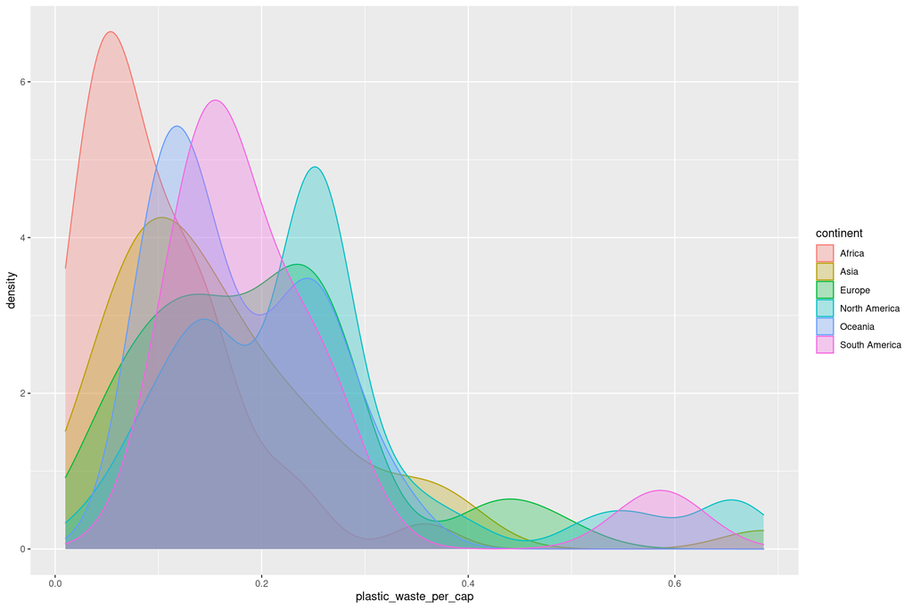

```r
ggplot(plastic,
       aes(x = plastic_waste_per_cap,
                     color = continent,
                     fill = continent)) +
  geom_density(alpha = 0.3)
```

## Ejercicio 6

Elabora una visualización alternativa a la anterior que permita comparar la distribución de cantidad de residuos de plástico per cápita de diferentes continentes.

### Solución

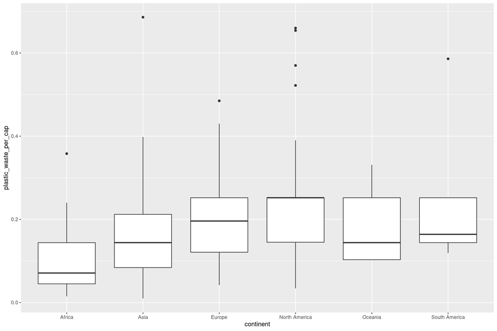

```r
ggplot(data = plastic,
       mapping = aes(x = continent,
                     y = plastic_waste_per_cap)) +
  geom_boxplot()
```

## Ejercicio 7

Investiga qué son las [gráficas violín](http://ggplot2.tidyverse.org/reference/geom_violin.html). Construye la gráfica de violín de los datos anteriores. ¿Qué revelan estas gráficas que un boxplot no revela?

¿Observas algún patrón que distinga la distribución de la cantidad de residuos de plástico de continentes desarrolladas y en vías de desarrollo?

### Solución

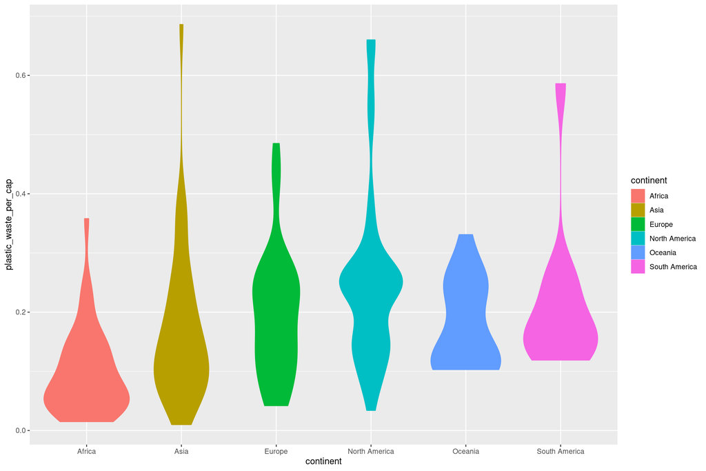

```r
ggplot(data = plastic,
       mapping = aes(x = continent,
                     y = plastic_waste_per_cap,
                     color = continent,
                     fill = continent)) +
  geom_violin()
```

En África, América Latina y Asia hay gran cantidad de países con pocos residuos y pocos con muchos residuos, mientras que en Europa, norteamérica y Oceanía la distribución es más homogénea.

## Ejercicio 8

Visualiza la relación entre cantidad de residuos de plástico per cápita y PIB per cápita. Pinta cada continente con un color y añade un **único smoothing** que muestre la tendencia global. Además, usa la escala de colores vidris (investiga en internet cómo utilizarla). ¿Cómo describirías esta relación?

### Solución

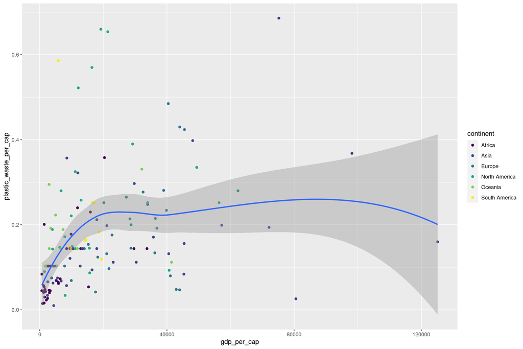

```r
ggplot(data=plastic, mapping = aes(x = gdp_per_cap,
                     y = plastic_waste_per_cap) ) +
  geom_point(aes(color = continent) ) + geom_smooth() + scale_color_viridis_d()
```

## Ejercicio 9

Repite la gráfica anterior pero únicamente incluyendo los datos de Europa (obviamente sin utilizar colores). ¿Qué tendencia observas? ¿Qué países consumen menos plástico de lo implicado por esta tendencia?

### Solución

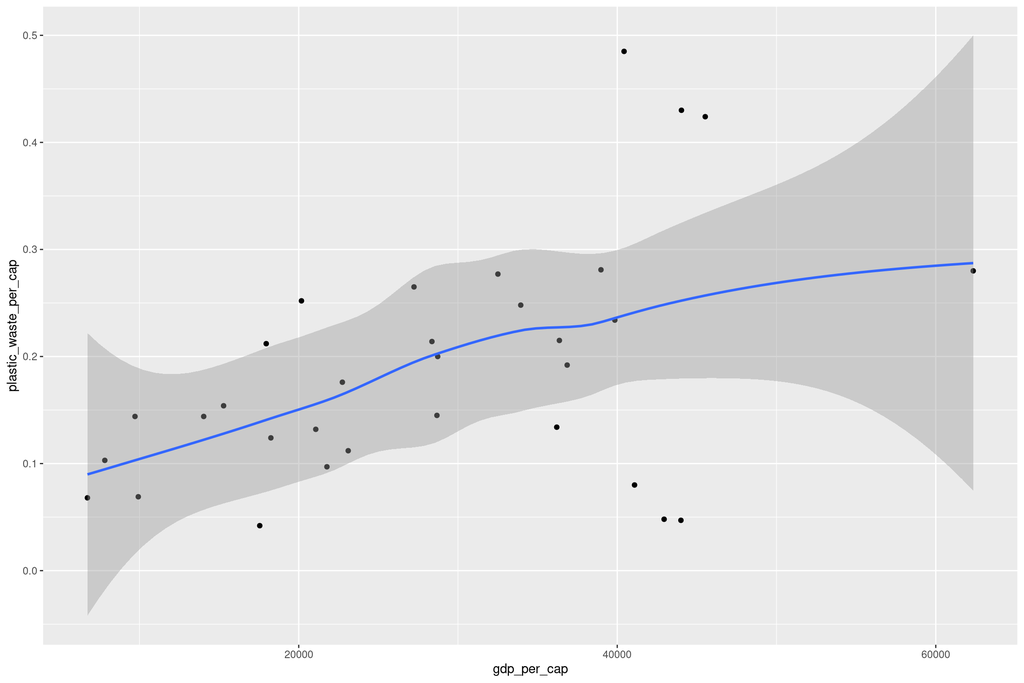

```r
plastic %>% filter(continent == "Europe") %>%
  ggplot(mapping = aes(x = gdp_per_cap,
                     y = plastic_waste_per_cap) ) +
  geom_point()  + geom_smooth()
```

```r
plastic %>%
  filter(continent == "Europe")  %>%
  filter(plastic_waste_per_cap < 0.1 & gdp_per_cap > 40000)
```

```
## # A tibble: 3 × 10
##   code  entity  continent  year gdp_per_cap plastic_waste_per_… mismanaged_plas…
##   <chr> <chr>   <chr>     <dbl>       <dbl>               <dbl>            <dbl>
## 1 BEL   Belgium Europe     2010      41086.               0.08             0.002
## 2 DNK   Denmark Europe     2010      43998.               0.047            0.001
## 3 SWE   Sweden  Europe     2010      42943.               0.048            0.001
## # … with 3 more variables: mismanaged_plastic_waste <dbl>, coastal_pop <dbl>,
## #   total_pop <dbl>
```

## Ejercicio 10

Visualiz la relación entre los residuos de plástico per cápita y los residuos mal gestionados per cápita. Pinta cada continente de un color. ¿Cambia la asociación de estas dos variables entre continentes?

### Solución

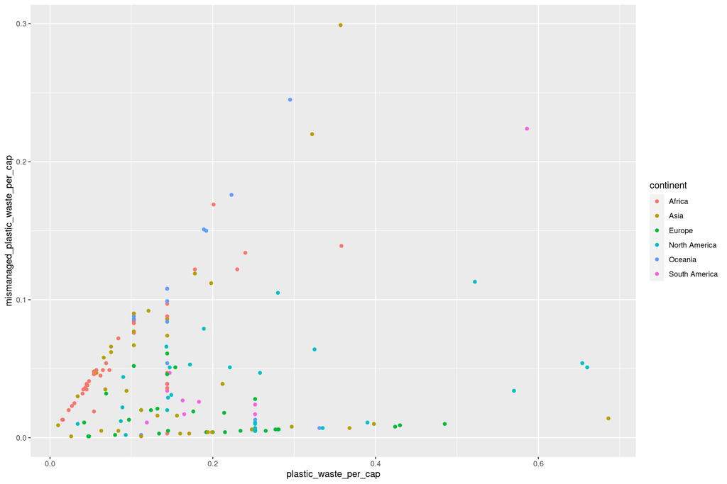

```r
ggplot(plastic, aes(x = plastic_waste_per_cap,
                    y = mismanaged_plastic_waste_per_cap, color=continent)) +
         geom_point()
```